# Intro to ggplot2

October 04, 2019

> These materials have been taken from the Software Carpentry: R Novice Lesson. You can find the original materials [here](https://github.com/swcarpentry/r-novice-gapminder).

Plotting our data is one of the best ways to quickly explore it and the various relationships between variables.

There are three main plotting systems in R, the [base plotting system](http://www.statmethods.net/graphs/index.html), the [lattice](http://www.statmethods.net/advgraphs/trellis.html) package, and the [ggplot2](http://www.statmethods.net/advgraphs/ggplot2.html) package.

Today we’ll be learning about the ggplot2 package because it is very effective for quickly creating publication quality graphics in a flexible way. It is especially useful for data exploration and multi-panel figures. ggplot2 is built on the “grammar of graphics,” the idea that any plot can be expressed from the same set of components: a **data** set, a **coordinate system**, and a set of **geoms**, the visual representation of data as *geometric* objects.

The key to understanding ggplot2 is thinking about a figure in layers. This idea may be familiar to you if you have used image editing programs like Photoshop, Illustrator, or Inkscape.

First, let’s make sure everything’s loaded:

```r
# Download the packages
# install.packages(c("tidyverse", "gapminder"))

# Load the packages for use
library(tidyverse)
library(gapminder)
```

## Simple ggplot

Let’s start off with an example:

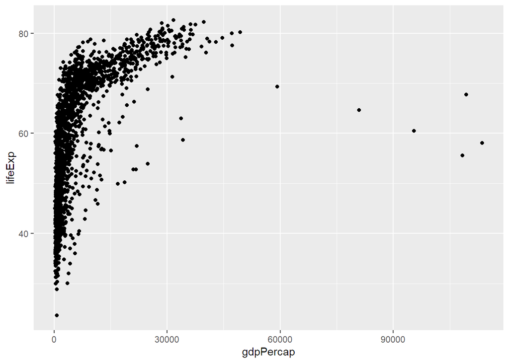

```r
ggplot(data = gapminder, aes(x = gdpPercap, y = lifeExp)) +
  geom_point()
```

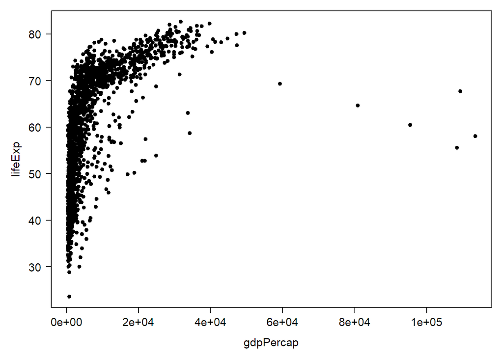

```r
plot( lifeExp ~ gdpPercap, gapminder )
```

So the first thing we do is call the `ggplot` function. This function lets R know that we’re creating a new plot, and any of the arguments we give the `ggplot` function are the *global* options for the plot: they apply to **all** layers on the plot, at least until we change them within specific **geoms**.

We’ve passed in two arguments to `ggplot`. First, we tell `ggplot` what data we want to show on our figure, in this example the gapminder data we read when we loaded the package `gapminder`. For the second argument we passed in the `aes` function, which tells `ggplot` how variables in the **data** map to *aesthetic* properties of the figure, in this case the **x** and **y** locations. Here we told `ggplot` to use gapminder column “gdpPercap” as the x-axis, and the column “lifeExp” as the y-axis.

By itself, the call to `ggplot` is only enough to create the space in which to display the data:

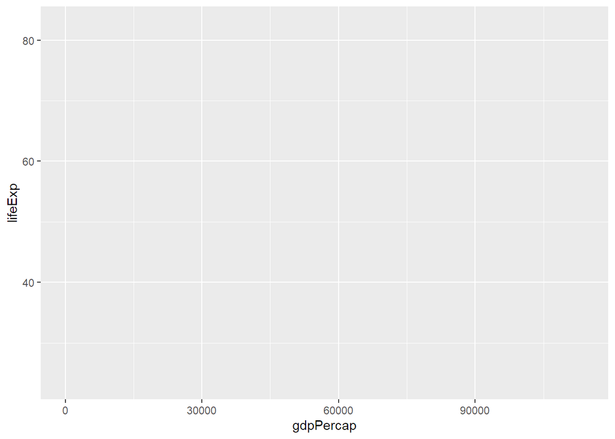

```r
ggplot(data = gapminder, aes(x = gdpPercap, y = lifeExp))
```

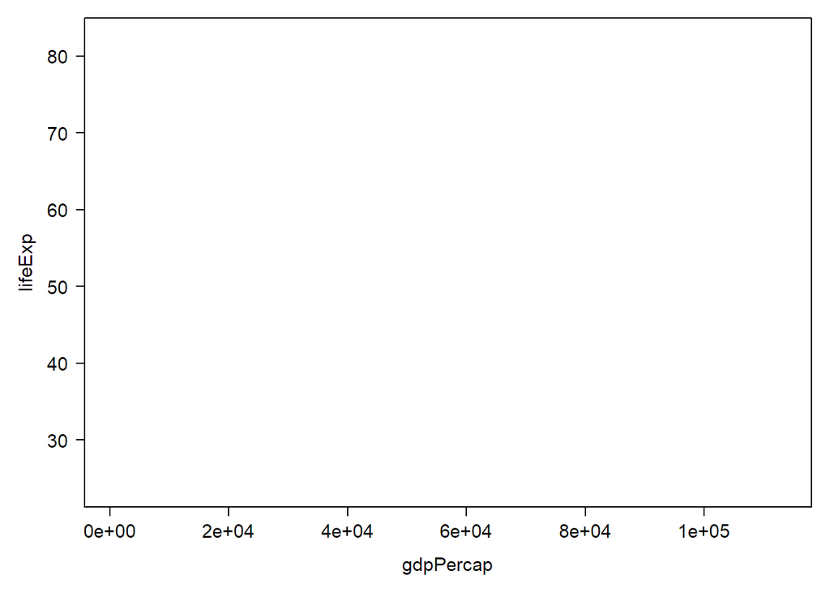

```r
plot( lifeExp ~ gdpPercap, gapminder, type='n' )
```

We need to tell `ggplot` how we want to visually represent the data, which we do by adding a new **geom** layer. In our example, we used `geom_point`, which tells `ggplot` we want to visually represent the relationship between **x** and **y** as a scatterplot of points:

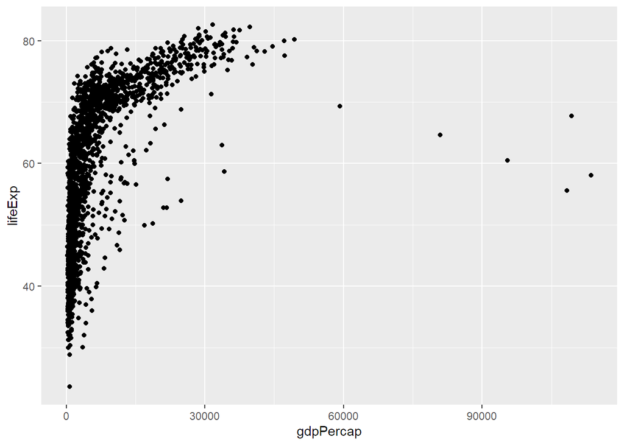

```r
ggplot(data = gapminder, aes(x = gdpPercap, y = lifeExp)) +
  geom_point()
```

### Challenge 1

Modify the example so that the figure shows how life expectancy has changed over time:

```r
# Previous example:
ggplot(data = gapminder, aes(x = gdpPercap, y = lifeExp)) +
  geom_point()
```

Hint: the gapminder dataset has a column called “year”, which should appear on the x-axis.

### Challenge 2

In the previous examples and challenge we’ve used the `aes` function to tell the scatterplot **geom** about the **x** and **y** locations of each point. Another *aesthetic* property we can modify is *colour*. Modify the code from the previous challenge to **colour** the points by the “continent” column. What trends do you see in the data? Are they what you expected?

### Solution to Challenge 2

## Layers

Using a scatterplot probably isn’t the best for visualizing change over time. Instead, let’s tell `ggplot` to visualize the data as a line plot. Here we’ll also shorten our code by omitting some of the declarations (e.g. x = year). By default, the first object passed to `ggplot()` is assumed to be the `data` argument. Similarly, the first two column names of `aes()` are assumed to be the x and y arguments.

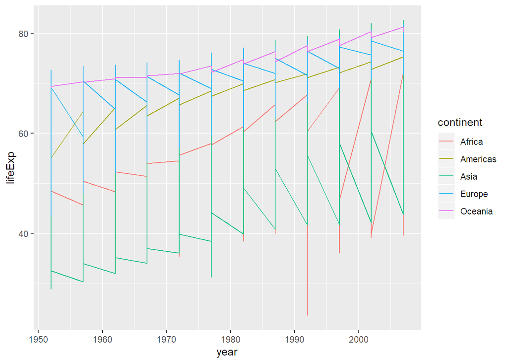

```r
ggplot(gapminder, aes(year, lifeExp, colour = continent)) +
  geom_line()
```

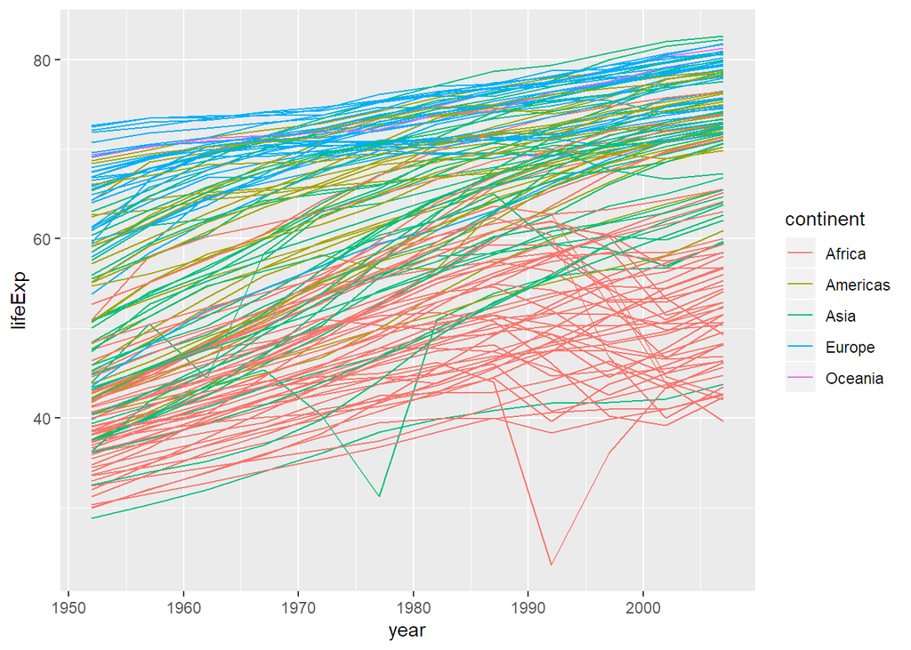

```r
ggplot(gapminder, aes(year, lifeExp, group = country, colour = continent)) +
  geom_line()
```

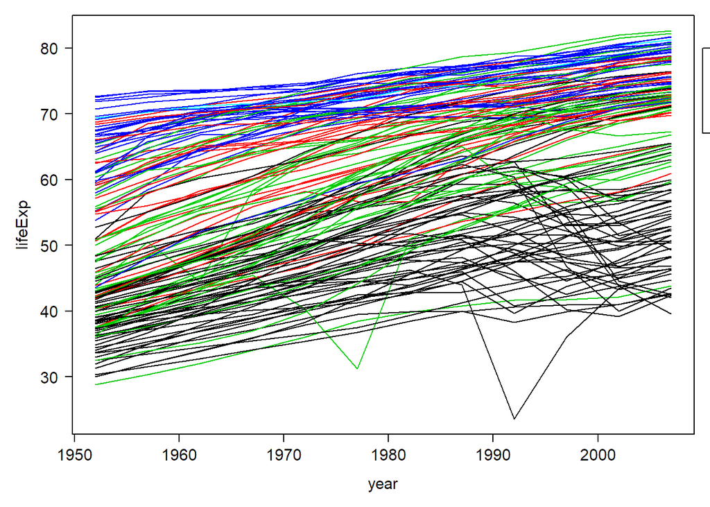

```r
plot( lifeExp ~ year, gapminder, type='n' )
for(i in unique(gapminder$country) ){
  lines( lifeExp ~ year, gapminder[gapminder$country==i,],
         col=as.numeric(gapminder$continent)[gapminder$country==i] )
}
legend( 2010, 80, legend = unique(gapminder$continent), col=1:length(unique(gapminder$continent)), pch=19 )
```

But what if we want to visualize both lines and points on the plot? We can simply add another layer to the plot:

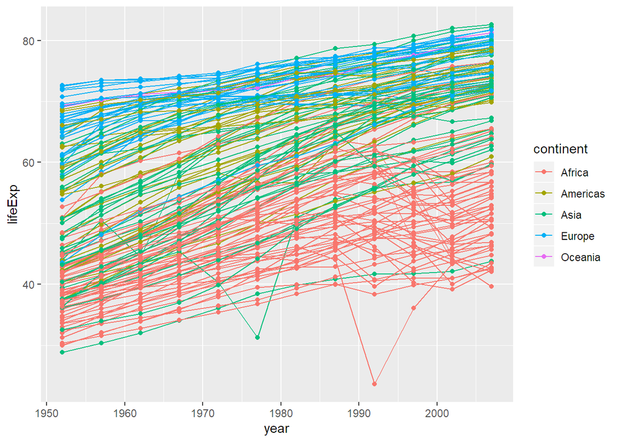

```r
ggplot(gapminder, aes(year, lifeExp, by = country, colour = continent)) +
  geom_line() +
  geom_point()
```

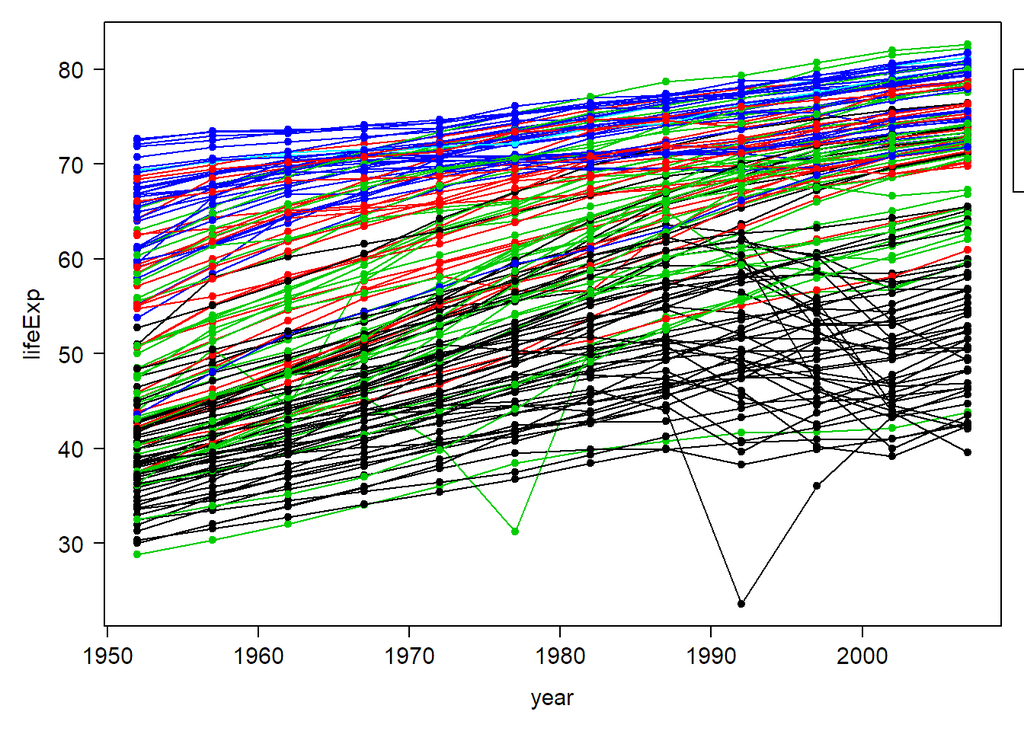

```r
plot( lifeExp ~ year, gapminder, type='n' )
for(i in unique(gapminder$country) ){
  lines( lifeExp ~ year, gapminder[gapminder$country==i,],
         col=as.numeric(gapminder$continent)[gapminder$country==i] )
}
points( lifeExp ~ year, gapminder, col=as.numeric(continent) )
legend( 2010, 80, legend = unique(gapminder$continent), col=1:length(unique(gapminder$continent)), pch=19 )
```

It’s important to note that each layer is drawn on top of the previous layer. In this example, the points have been drawn *on top of* the lines. Here’s a demonstration:

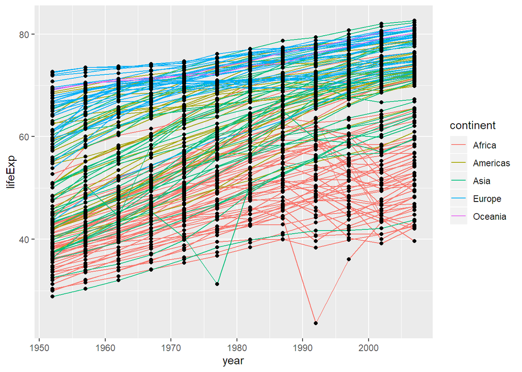

```r
ggplot(gapminder, aes(year, lifeExp, by = country)) +
  geom_line(aes(colour = continent)) +
  geom_point()
```

In this example, the *aesthetic* mapping of **colour** has been moved from the global plot options in `ggplot` to the `geom_line` layer so it no longer applies to the points. Now we can clearly see that the points are drawn on top of the lines.

### Tip: Setting an aesthetic to a value instead of a mapping

So far, we’ve seen how to use an aesthetic (such as **colour**) as a *mapping* to a variable in the data. For example, when we use `geom_line(aes(colour = continent))`, ggplot will give a different colour to each continent. But what if we want to change the colour of all lines to blue? You may think that `geom_line(aes(colour = "blue"))` should work, but it doesn’t. Since we don’t want to create a mapping to a specific variable, we simply move the colour specification outside of the `aes()` function, like this: `geom_line(colour = "blue")`.

### Challenge 3

Switch the order of the point and line layers from the previous example. What happened?

### Solution to Challenge 3

Switch the order of the point and line layers from the previous example. What happened?

The lines now get drawn over the points!

## Transformations and statistics

ggplot2 also makes it easy to overlay statistical models over the data. To demonstrate we’ll go back to our first example:

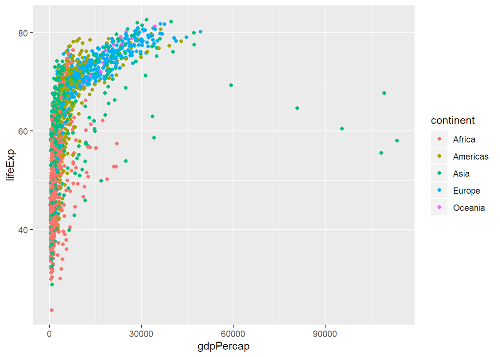

```r
ggplot(gapminder, aes(gdpPercap, lifeExp, colour = continent)) +
  geom_point()
```

Currently it’s hard to see the relationship between the points due to some strong outliers in GDP per capita and the saturating nature of the relationship (no one lives forever!). We can change the scale of units on the x axis using the *scale* functions. These control the mapping between the data values and visual values of an aesthetic. We can also modify the transparency of the points, using the *alpha* function, which is especially helpful when you have a large amount of data which is very clustered.

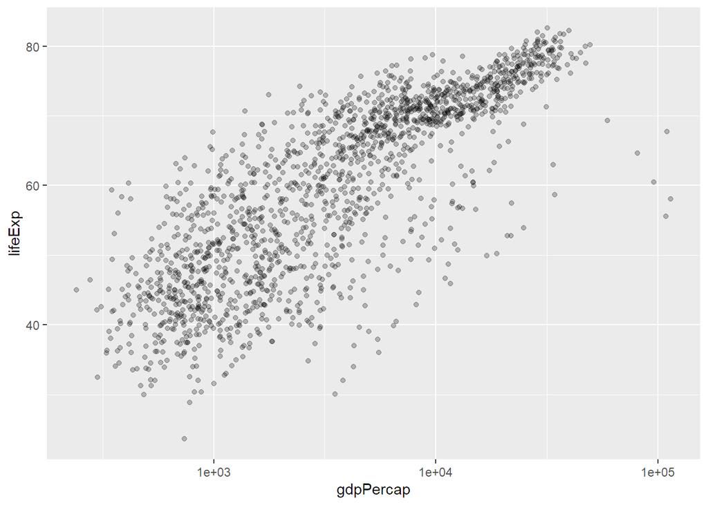

```r
ggplot(gapminder, aes(gdpPercap, lifeExp)) +
  geom_point(alpha = 0.25) +
  scale_x_log10()
```

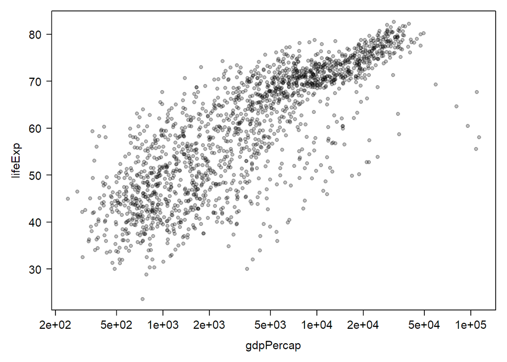

```r
par(mar=c(5,5,1,1)+0.1)
plot( lifeExp ~ gdpPercap, gapminder, log='x', col=rgb(0,0,0,0.25) )
```

The `log10` function applied a transformation to the values of the gdpPercap column before rendering them on the plot, so that each multiple of 10 now only corresponds to an increase in 1 on the transformed scale, i.e., the distance between a GDP per capita of 1,000 (1e+03) and 10,000 (1e+04) is the same as the distance between 10,000 and 100,000 (1e+05).

### Reminder: Setting an aesthetic to a value instead of a mapping

Notice that we used `geom_point(alpha = 0.25)`. As the previous tip mentioned, using a setting outside of the `aes()` function will cause this value to be used for all points, which is what we want in this case. But just like any other aesthetic setting, *alpha* can also be mapped to a variable in the data. For example, we can give a different transparency to each continent with `geom_point(aes(alpha = continent))`.

We can fit a simple relationship to the data by adding another layer, `geom_smooth`:

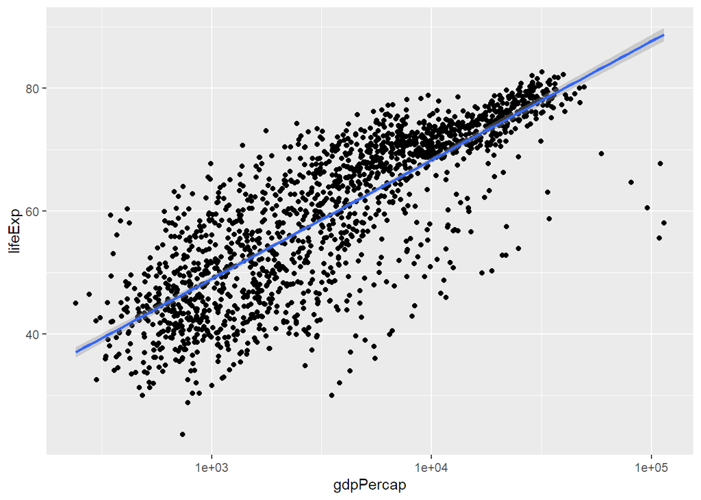

```r
ggplot(gapminder, aes(gdpPercap, lifeExp)) +
  geom_point() +
  scale_x_log10() +
  geom_smooth(method = "lm")
```

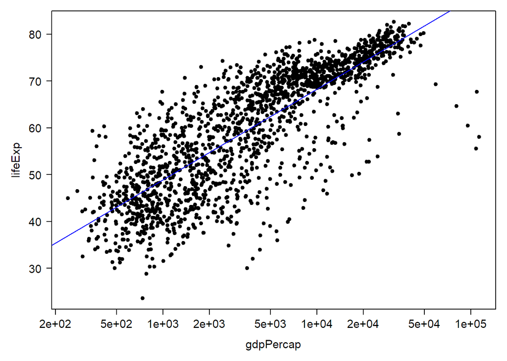

```r
par(xpd=F)
plot( lifeExp~gdpPercap, gapminder, log='x' )
reg <- lm(lifeExp~log10(gdpPercap), gapminder)
abline(reg,col='blue')
```

We can make the line thicker by *setting* the **size** aesthetic in the `geom_smooth` layer:

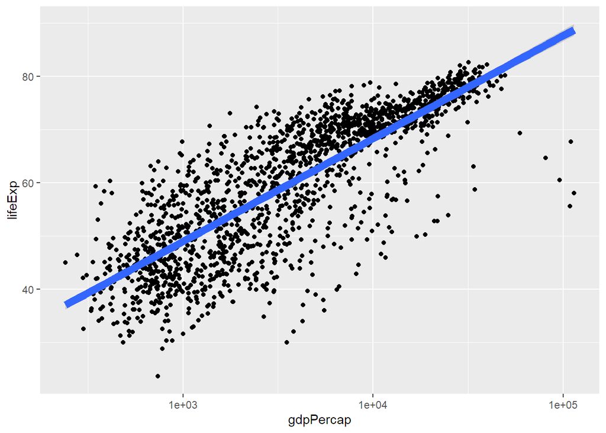

```r
ggplot(gapminder, aes(gdpPercap, lifeExp)) +
  geom_point() +
  scale_x_log10() +
  geom_smooth(method = "lm", size = 3 )
```

There are two ways an *aesthetic* can be specified. Here we *set* the **size** aesthetic by passing it as an argument to `geom_smooth`. Previously in the lesson we’ve used the `aes` function to define a *mapping* between data variables and their visual representation.

### Challenge 4a

Modify the colour and size of the points on the point layer in the previous example. Hint: do not use the `aes` function.

### Solution to challenge 4a

Learn more about [Colors in R](http://www.stat.columbia.edu/~tzheng/files/Rcolor.pdf)

### Challenge 4b

Modify your solution to Challenge 4a so that the points are now a different shape and are coloured by continent with new trendlines. Hint: The colour argument can be used inside the aesthetic.

### Solution to Challenge 4b

Modify Challenge 4 so that the points are now a different shape and are coloured by continent with new trendlines. Hint: The colour argument can be used inside the aesthetic.

## Multi-panel figures

Earlier we visualized the change in life expectancy over time across all countries in one plot. Alternatively, we can split this out over multiple panels by adding a layer of **facet** panels. Here we will first make a smaller version of the data to make it easier to work with. The `%in%` operator just means that country must be equal to one of four specified countries.

[figure not shown]

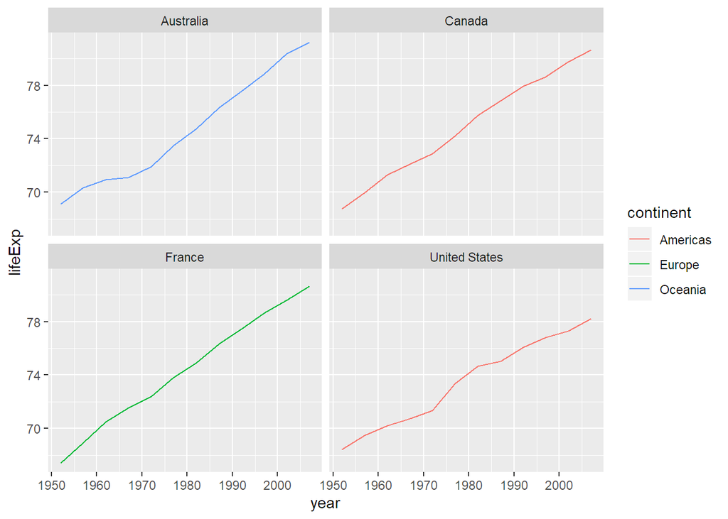

```r
gapminder_small <- gapminder %>%
  filter(country %in% c("Canada", "United States", "France", "Australia"))

ggplot(gapminder_small, aes(year, lifeExp, colour = continent)) +
  geom_line() +
  facet_wrap(~country)
```

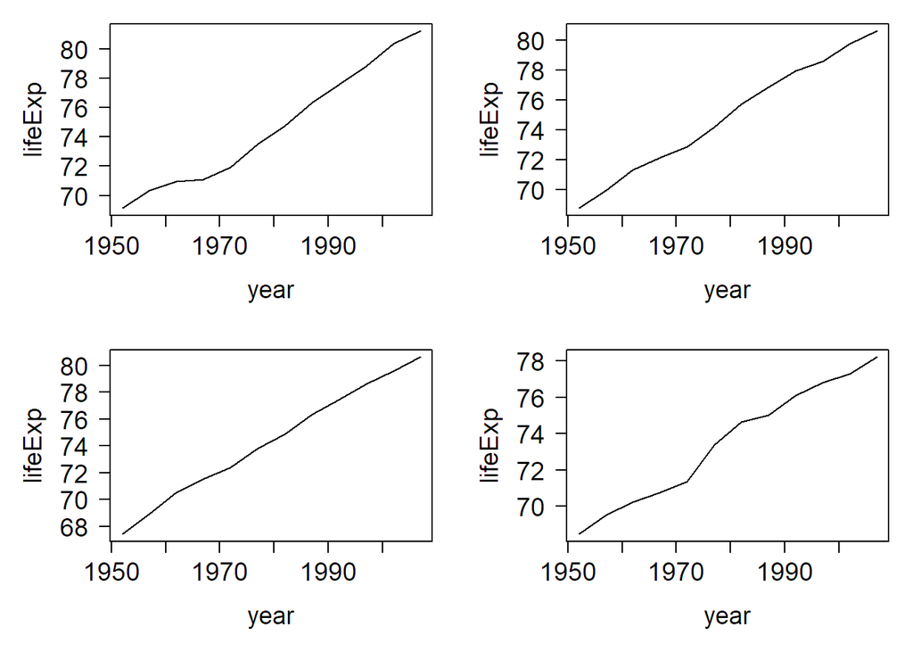

```r
par(mfrow=c(2,2))
for(i in unique(gapminder_small$country)){
  plot(lifeExp~year,gapminder_small[gapminder_small$country==i,],
       type='l')
}
```

```r
par(mfrow=c(1,1))
```

The `facet_wrap` layer took a “formula” as its argument, denoted by the tilde (`~`). This tells R to draw a panel for each unique value in the country column of the `gapminder_small` data.

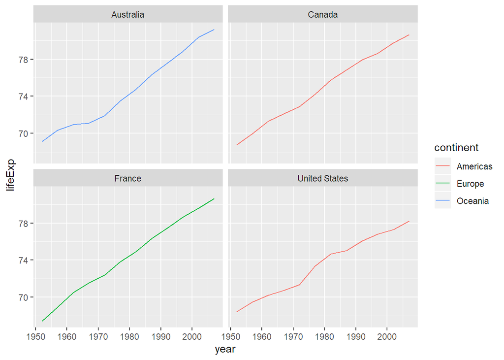

```r
ggplot(gapminder_small, aes(year, lifeExp, colour = continent)) +
  geom_line() +
  facet_wrap(~country)
```

## Modifying text

To clean this figure up for a publication we need to change some of the text elements. The x-axis is too cluttered, and the y axis should read “Life expectancy”, rather than the column name in the data frame.

We can do this by adding a couple of different layers. The **theme** layer controls the axis text, and overall text size. Labels for the axes, plot title and any legend can be set using the `labs` function. Legend titles are set using the same names we used in the `aes` specification. Thus below the colour legend title is set using `colour = "Continent"`, while the title of a fill legend would be set using `fill = "MyTitle"`.

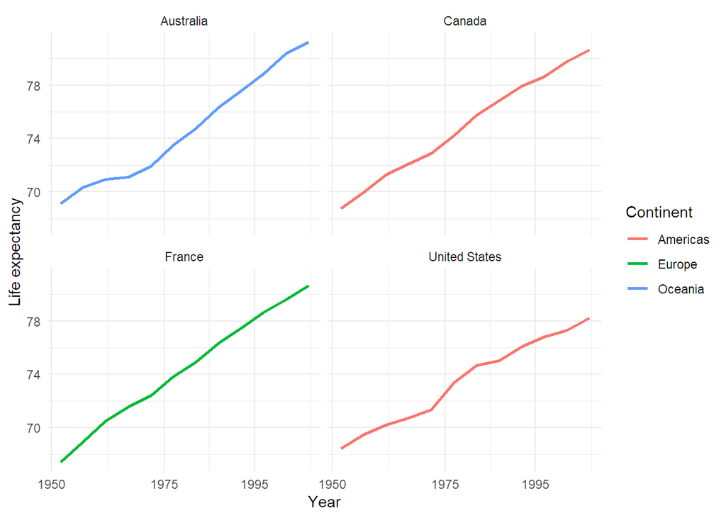

```r
ggplot(gapminder_small, aes(year, lifeExp, colour = continent)) +
  geom_line(size=1) +
  facet_wrap(~country) +
  labs(x = "Year", y = "Life expectancy", colour = "Continent") +
  scale_x_continuous( breaks=c(1950,1975,1995)) +
  theme_minimal() +  # see ?theme and ?theme_minimal
  theme(axis.ticks.x = element_blank())
```

## Exporting a plot

```r
lifeExp_plot <- ggplot(gapminder_small, aes(year, lifeExp, colour = continent)) +
  geom_line() +
  facet_wrap(~country) +
  labs(x = "Year", y = "Life expectancy", colour = "Continent") +
  scale_x_continuous( breaks=c(1950,1975,1995)) +
  theme_minimal() +
  theme(axis.ticks.x = element_blank())

ggsave(plot = lifeExp_plot, filename = "lifeExp.png", units = "cm", width = 12, height = 10, dpi = 300)
```

There are two nice things about `ggsave`. First, it defaults to the last plot, so if you omit the `plot` argument it will automatically save the last plot you created with `ggplot`. Secondly, it tries to determine the format you want to save your plot in from the file extension you provide for the filename (for example `.png` or `.pdf`). If you need to, you can specify the format explicitly in the `device` argument.

## Summary

This is a taste of what you can do with ggplot2. RStudio provides a really useful [cheat sheet](http://www.rstudio.com/wp-content/uploads/2015/03/ggplot2-cheatsheet.pdf) of the different layers available, and more extensive documentation is available on the [ggplot2 website](http://docs.ggplot2.org/current/). Finally, if you have no idea how to change something, a quick Google search will usually send you to a relevant question and answer on Stack Overflow with reusable code to modify!

### Challenge 5

Create a density plot of GDP per capita, filled by continent.

Advanced:

- Transform the x axis to better visualise the data spread
- Add a facet layer to panel the density plots by year
- Make the y-axis range independent for each facet (year)

### Solution to Challenge 5

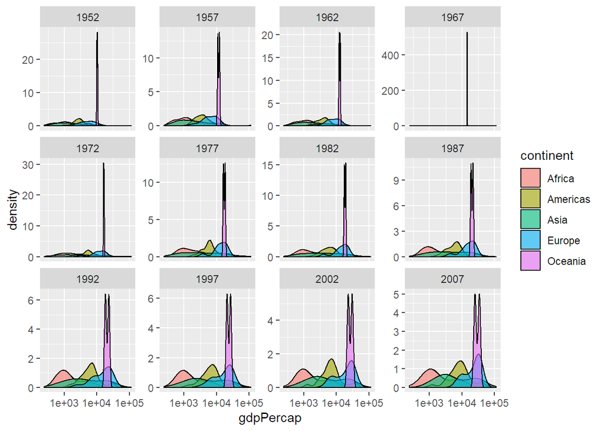

```r
ggplot(gapminder, aes(gdpPercap, fill = continent)) +
  geom_density(alpha = 0.6) +
  facet_wrap(~year, scales = "free_y") +
  scale_x_log10()
```

## A Few additional examples of functionality we didn’t have time to cover

### stat summaries

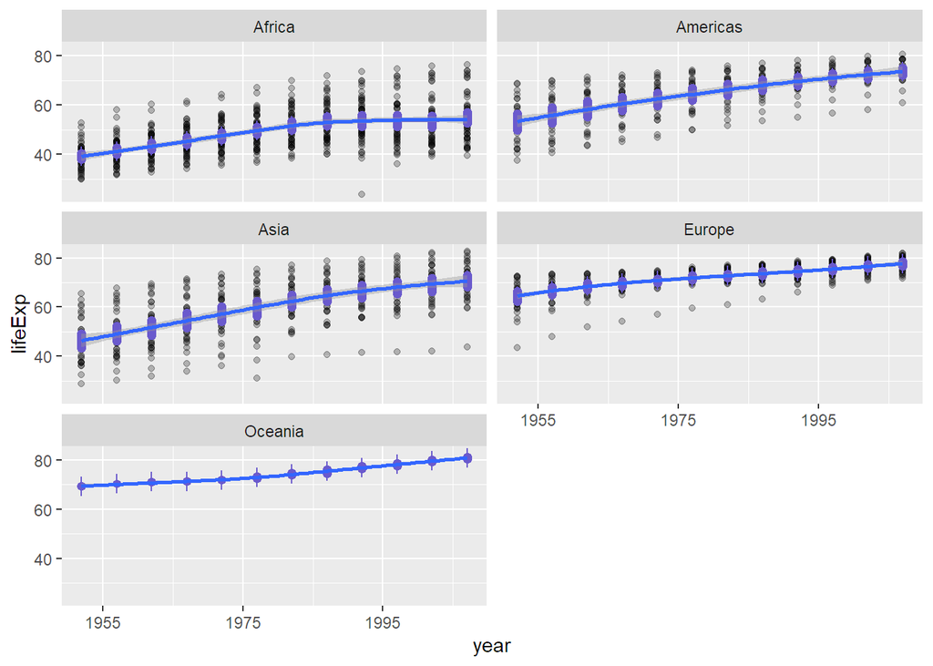

```r
stat_sum_df <- function(fun, geom="crossbar", ...) {
  stat_summary(fun.data=fun, colour="slateblue", geom=geom, width=0.2, size=2, ...)
}
(lifeExp_plot2 <- ggplot(gapminder, aes( x=year, y=lifeExp)) +
  facet_wrap(~continent, ncol = 2) +
  geom_point(col='black',alpha = 0.25) +
  stat_summary( fun.y = mean, geom = "line", col='slateblue' ) +
  stat_sum_df("mean_cl_boot") +
  geom_smooth() +
  scale_x_continuous( breaks=c(1955,1975,1995)))
```

```r
ggsave(plot = lifeExp_plot2, filename = "lifeExp2.png", units = "cm", width = 6, height = 8, dpi = 300)
```

### Adding dimensionality to bivariate plots

### color gradients

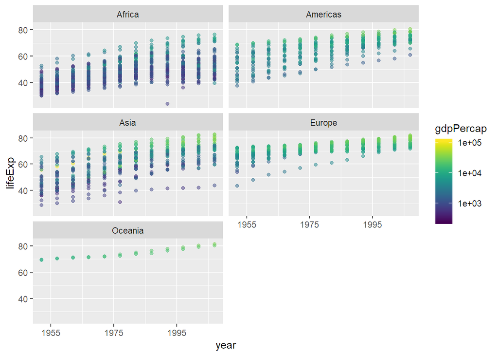

```r
library(viridis)
ggplot(gapminder, aes( x=year, y=lifeExp, col=gdpPercap)) +
  facet_wrap(~continent, ncol = 2) +
  geom_point(alpha = 0.5) +
  scale_x_continuous( breaks=c(1955,1975,1995)) +
  scale_color_viridis(trans="log10")
```

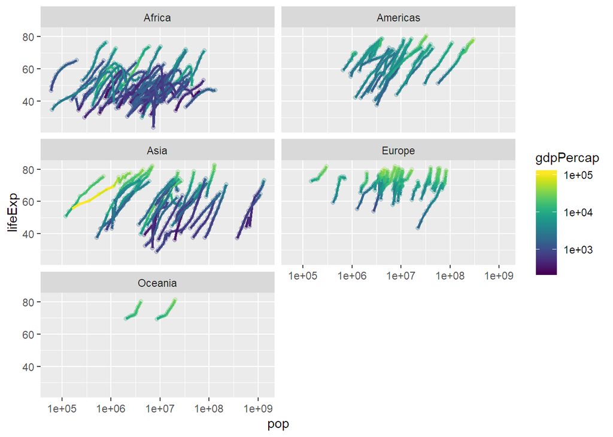

```r
ggplot(gapminder, aes( x=pop, y=lifeExp, col=gdpPercap)) +
  facet_wrap(~continent, ncol = 2) +
  geom_point(alpha = 0.25) +
  geom_line(aes(group=country),size=1) +
  scale_x_log10() +
  scale_color_viridis(trans="log10")
```

### point size

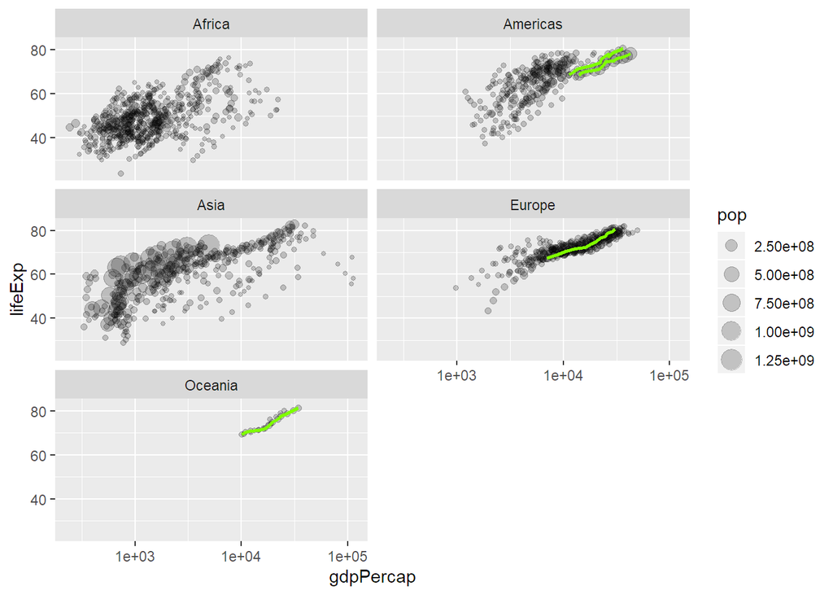

```r
ggplot(gapminder, aes( x=gdpPercap, y=lifeExp, size=pop)) +
  facet_wrap(~continent, ncol = 2) +
  geom_point(alpha = 0.2) +
  geom_line( data=gapminder_small, aes(group=country), size=1, col='chartreuse' ) +
  scale_x_log10()
```